# NHL Stanley Cup Playoff Predictions

Ilari Scheinin

Previous: 3. Train models  
Next: [README](https://github.com/ilarischeinin/stanley)

## 4. Make predictions

In the previous step, five different types of models (glm, lda, nnet, rf, svmLinear) were fitted to the training data of NHL seasons from 2003 to 2014. Now I want to use those models to make predictions for this year.

Start by loading packages:

```r
suppressMessages({
  library(plyr)
  library(dplyr)
  library(caret)
})
```

Load the models and summary statistics.

```r
gamestats <- readRDS("processed.rds")
models <- readRDS("models.rds")
```

Any one of the five models could be used to make predictions. One could for example pick the one with the highest accuracy or [Kappa statistic](https://en.wikipedia.org/wiki/Cohen%27s_kappa). Each model contains these metrics for each combination of parameter values that were evalauted through cross-validation. The parameters with the highest accuracy were chosen for fitting the final model. The following function returns the cross-validated metric for the final model.

```r
metric_for_final_parameters <- function(fit, metric="Accuracy") {
  if (fit$maximize) {
    chosen <- which.max(fit$result[, fit$metric])
  } else {
    chosen <- which.min(fit$result[, fit$metric])
  }
  fit$result[chosen, metric]
}

which.max(sapply(models, metric_for_final_parameters))
```

```
## rf
##  4
```

```r
which.max(sapply(models, metric_for_final_parameters, metric="Kappa"))
```

```
## rf
##  4
```

We can also look at the performance over all resamplings.

```r
resamps <- resamples(models)
summary(resamps)
```

```
##
## Call:
## summary.resamples(object = resamps)
##
## Models: glm, lda, nnet, rf, svmLinear
## Number of resamples: 100
##
## Accuracy
##             Min. 1st Qu. Median   Mean 3rd Qu.   Max. NA's
## glm       0.3750  0.5625 0.6250 0.6291  0.7059 0.8824    0
## lda       0.3750  0.5625 0.6360 0.6351  0.7059 0.8824    0
## nnet      0.4375  0.5542 0.6250 0.6221  0.6875 0.8824    0
## rf        0.2941  0.5625 0.6471 0.6464  0.7059 0.8824    0
## svmLinear 0.4118  0.5294 0.6250 0.6274  0.7059 0.8824    0
##
## Kappa
##              Min. 1st Qu. Median   Mean 3rd Qu.   Max. NA's
## glm       -0.2698 0.06849 0.2381 0.2272  0.3761 0.7463    0
## lda       -0.2698 0.06804 0.2381 0.2402  0.3796 0.7463    0
## nnet      -0.1168 0.09677 0.2131 0.2406  0.3599 0.7671    0
## rf        -0.3973 0.09160 0.2388 0.2533  0.3796 0.7571    0
## svmLinear -0.2687 0.06849 0.2381 0.2260  0.3761 0.7463    0
```

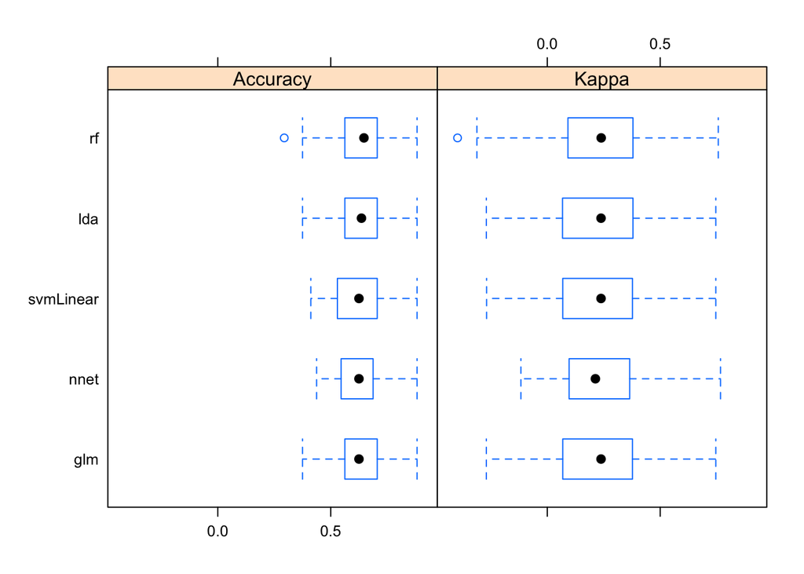

```r
bwplot(resamps, layout=c(2, 1))
```

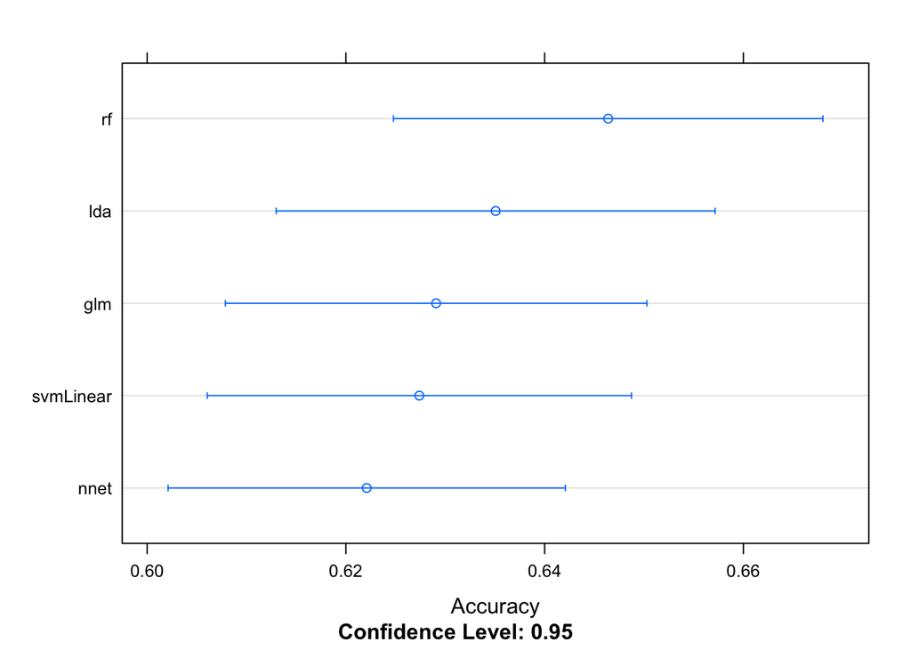

```r
dotplot(resamps, metric="Accuracy")
```

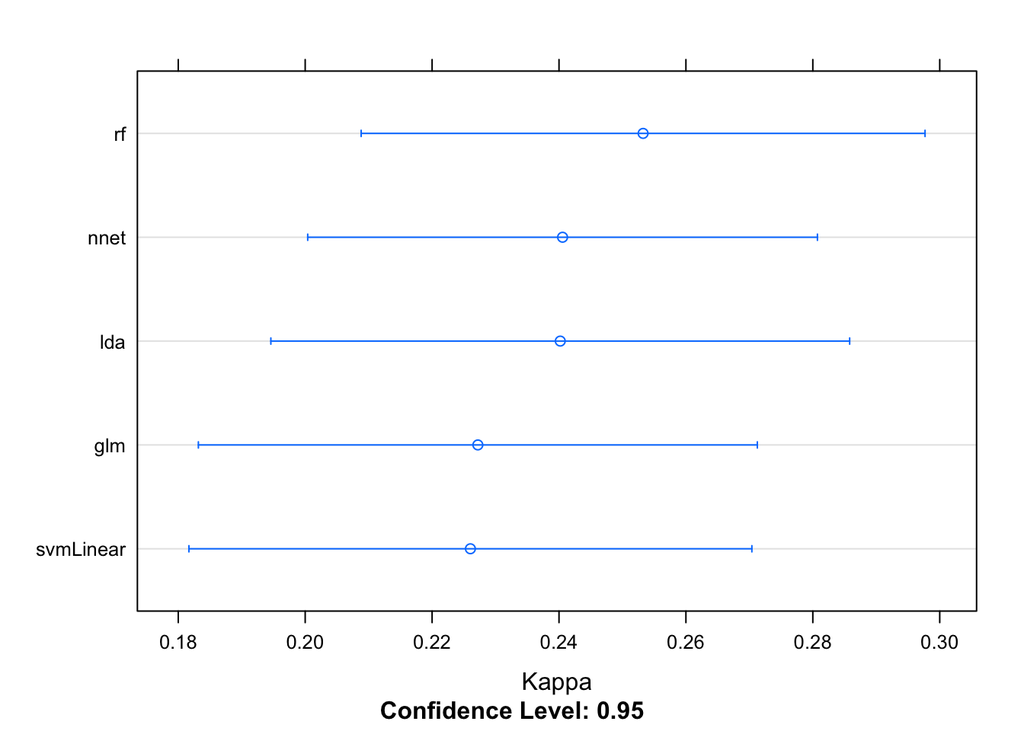

```r
dotplot(resamps, metric="Kappa")
```

So, if I were to choose one of the models, overall the random forest could be a god choice. But instead of picking just one, here I will use all five, and then take a majority vote on their individual predictions. Here is the function to do that:

```r
winners <- function(games, models, gamestats) {
  suppressMessages({ captured <- capture.output({
    predictions <- as.data.frame(sapply(models, predict,
      newdata=add_stats(games, gamestats)))
  })})
  if (nrow(games) == 1) {
    predictions <- as.data.frame(t(predictions))
    row.names(predictions) <- NULL
  }
  predictions$winner <- apply(predictions, 1, function(x)
    names(sort(table(x), decreasing=TRUE))[1])
  predictions <- ifelse(predictions == "away", games$awayteam, games$hometeam)
  cbind(games, predictions)
}
```

I also need to include the same `add_stats()` function that was used when training the models.

```r
add_stats <- function(games, gamestats, which=c("both", "single", "overall")) {
  which <- match.arg(which)
  if (which == "overall") {
    away <- left_join(games, gamestats[["overall"]],
      by=c("season", awayteam="team"))
    home <- left_join(games, gamestats[["overall"]],
      by=c("season", hometeam="team"))
  } else {
    away <- left_join(games, gamestats[["away"]],
      by=c("season", awayteam="team"))
    home <- left_join(games, gamestats[["home"]],
      by=c("season", hometeam="team"))
  }

  if (which == "both") {
    away2 <- left_join(games, gamestats[["home"]],
      by=c("season", awayteam="team"))
    home2 <- left_join(games, gamestats[["away"]],
      by=c("season", hometeam="team"))
  }

  games$goals <- away$goals - home$goals
  games$shots <- away$shots - home$shots
  games$faceoffs <- away$faceoffs - home$faceoffs
  games$penalties <- away$penalties - home$penalties
  games$pp <- away$pp - home$pk
  games$pk <- away$pk - home$pp

  if (which == "both") {
    games$goals2 <- away2$goals - home2$goals
    games$shots2 <- away2$shots - home2$shots
    games$faceoffs2 <- away2$faceoffs - home2$faceoffs
    games$penalties2 <- away2$penalties - home2$penalties
    games$pp2 <- away2$pp - home2$pk
    games$pk2 <- away2$pk - home2$pp
  }

  games
}
```

Before I can go on to the predictions, I need to define who is playing against who. Here I define the actual playoff games for round 1, and all possible combinations of the playoff bracket for subsequent rounds.

```r
round1_games <- data_frame(season="20142015",
  awayteam=c("PIT", "OTT", "DET", "NYI", "WPG", "MIN", "CHI", "CGY"),
  hometeam=c("NYR", "MTL", "T.B", "WSH", "ANA", "STL", "NSH", "VAN"))

round2_possibilities <- data_frame(season="20142015",
  awayteam=c(
        "WSH", "NYI", "T.B", "DET", "OTT", "OTT", "PIT", "PIT",
    "VAN", "CGY", "NSH", "CHI", "MIN", "MIN", "WPG", "CGY"),
  hometeam=c(
        "NYR", "NYR", "MTL", "MTL", "T.B", "DET", "WSH", "NYI",
    "ANA", "ANA", "STL", "STL", "NSH", "CHI", "VAN", "WPG"))

round3_possibilities <- data_frame(season="20142015",
  awayteam=c(
    "MTL", "T.B", "DET", "OTT",
    "WSH", "NYI", "PIT",
    "WSH", "NYI", "PIT",
    "DET", "OTT",
    "DET", "OTT",
    "PIT",
    "PIT",
    "STL", "NSH", "CHI", "MIN",
    "VAN", "WPG", "CGY",
    "VAN", "WPG", "CGY",
    "VAN", "WPG", "CGY",
    "MIN",
    "WPG", "CGY"),
  hometeam=c(
    "NYR", "NYR", "NYR", "NYR",
    "MTL", "MTL", "MTL",
    "T.B", "T.B", "T.B",
    "WSH", "WSH",
    "NYI", "NYI",
    "DET",
    "OTT",
    "ANA", "ANA", "ANA", "ANA",
    "STL", "STL", "STL",
    "NSH", "NSH", "NSH",
    "CHI", "CHI", "CHI",
    "VAN",
    "MIN", "MIN"))

round4_possibilities <- data_frame(season="20142015",
  awayteam=c(
    "ANA", "STL", "NSH", "CHI", "VAN", "MIN", "WPG", "CGY",
    "ANA", "STL", "NSH", "CHI", "VAN", "MIN", "WPG", "CGY",
    "T.B", "WSH", "NYI", "DET", "OTT", "PIT",
    "T.B", "WSH", "NYI", "DET", "OTT", "PIT",
    "NSH", "CHI", "VAN", "MIN", "WPG", "CGY",
    "WSH", "NYI", "DET", "OTT", "PIT",
    "WSH", "NYI", "DET", "OTT", "PIT",
    "WSH", "NYI", "DET", "OTT", "PIT",
    "MIN", "WPG", "CGY",
    "MIN", "WPG", "CGY",
    "DET", "OTT", "PIT",
    "WPG", "CGY",
    "WPG", "CGY",
    "PIT",
    "CGY"),
  hometeam=c(
    "NYR", "NYR", "NYR", "NYR", "NYR", "NYR", "NYR", "NYR",
    "MTL", "MTL", "MTL", "MTL", "MTL", "MTL", "MTL", "MTL",
    "ANA", "ANA", "ANA", "ANA", "ANA", "ANA",
    "STL", "STL", "STL", "STL", "STL", "STL",
    "T.B", "T.B", "T.B", "T.B", "T.B", "T.B",
    "NSH", "NSH", "NSH", "NSH", "NSH",
    "CHI", "CHI", "CHI", "CHI", "CHI",
    "VAN", "VAN", "VAN", "VAN", "VAN",
    "WSH", "WSH", "WSH",
    "NYI", "NYI", "NYI",
    "MIN", "MIN", "MIN",
    "DET", "DET",
    "OTT", "OTT",
    "WPG",
    "PIT"))
```

And then finally to the predictions:

```r
round1 <- winners(round1_games, models, gamestats)
round1
```

```
##     season awayteam hometeam glm lda nnet  rf svmLinear winner
## 1 20142015      PIT      NYR NYR NYR  NYR PIT       NYR    NYR
## 2 20142015      OTT      MTL MTL MTL  MTL MTL       MTL    MTL
## 3 20142015      DET      T.B T.B T.B  T.B T.B       T.B    T.B
## 4 20142015      NYI      WSH NYI NYI  NYI NYI       NYI    NYI
## 5 20142015      WPG      ANA ANA ANA  ANA WPG       ANA    ANA
## 6 20142015      MIN      STL STL STL  MIN STL       STL    STL
## 7 20142015      CHI      NSH CHI CHI  CHI CHI       CHI    CHI
## 8 20142015      CGY      VAN CGY CGY  CGY VAN       CGY    CGY
```

Now that I have predictions for round 1 winners, I pick only their games from all the possibilities for round 2:

```r
round2 <- winners(
  filter(round2_possibilities,
    awayteam %in% round1$winner, hometeam %in% round1$winner),
  models, gamestats)
round2
```

```
##     season awayteam hometeam glm lda nnet  rf svmLinear winner
## 1 20142015      NYI      NYR NYR NYR  NYR NYR       NYI    NYR
## 2 20142015      T.B      MTL MTL MTL  MTL MTL       MTL    MTL
## 3 20142015      CGY      ANA ANA ANA  CGY ANA       CGY    ANA
## 4 20142015      CHI      STL CHI CHI  CHI STL       CHI    CHI
```

Similarly for round 3, the conference finals:

```r
round3 <- winners(
  filter(round3_possibilities,
    awayteam %in% round2$winner, hometeam %in% round2$winner),
  models, gamestats)
round3
```

```
##     season awayteam hometeam glm lda nnet  rf svmLinear winner
## 1 20142015      MTL      NYR NYR NYR  NYR NYR       NYR    NYR
## 2 20142015      CHI      ANA CHI CHI  CHI ANA       CHI    CHI
```

And finally the Stanley Cup final:

```r
round4 <- winners(
  filter(round4_possibilities,
    awayteam %in% round3$winner, hometeam %in% round3$winner),
  models, gamestats)
round4
```

```
##     season awayteam hometeam glm lda nnet  rf svmLinear winner
## 1 20142015      CHI      NYR CHI CHI  CHI CHI       CHI    CHI
```

My prediction for the 2015 Stanley Cup winner is **Chicago Blackhawks**.

### Validation

As the 2014-2015 playoffs are now over, we have our natural validation set available. (Since I could have naturally tampered with the prediction process after the fact to try to get to the real outcome, here is a link to the first GitHub [commit](https://github.com/ilarischeinin/stanley/blob/30c3838f629261796895ecd271d327fb7cabd543/predict.html) that included my predictions. It was made on April 23rd. So, not before the playoffs started on April 15th, but when round 1 was already 3-4 games in, depending on the series.)

The prediction of Chicago Blackhawks as the the Stanley Cup winner turned out to be correct. But in the finals they played against Tampa Bay Lightning, not New York Rangers. So, let us look at predictions for the playoff series that actually ended up happening. Round 1 is of course as above, but my model got two of those series wrong. Instead of New York Islanders and St. Louis Blues, it was Washington Capitals and Minnesota Wild who made it to the second round.

```r
round2_games <- data_frame(season="20142015",
  awayteam=c("WSH", "T.B", "CGY", "MIN"),
  hometeam=c("NYR", "MTL", "ANA", "CHI"))
winners(round2_games, models, gamestats)
```

```
##     season awayteam hometeam glm lda nnet  rf svmLinear winner
## 1 20142015      WSH      NYR NYR NYR  WSH NYR       NYR    NYR
## 2 20142015      T.B      MTL MTL MTL  MTL MTL       MTL    MTL
## 3 20142015      CGY      ANA ANA ANA  CGY ANA       CGY    ANA
## 4 20142015      MIN      CHI CHI CHI  MIN MIN       CHI    CHI
```

Here one of the predictions was wrong. Instead of Montreal Canadians, it was Tampa Bay Lightning who made it to the Eastern Conference final.

```r
round3_games <- data_frame(season="20142015",
  awayteam=c("T.B", "CHI"),
  hometeam=c("NYR", "ANA"))
winners(round3_games, models, gamestats)
```

```
##     season awayteam hometeam glm lda nnet  rf svmLinear winner
## 1 20142015      T.B      NYR NYR NYR  T.B T.B       NYR    NYR
## 2 20142015      CHI      ANA CHI CHI  CHI ANA       CHI    CHI
```

Again, one of the predictions was wrong. In the Stanley Cup final, Chicago Blackhawks faced Tampa Bay Lightning, not New York Rangers.

```r
round4_games <- data_frame(season="20142015",
  awayteam=c("CHI"),
  hometeam=c("T.B"))
winners(round4_games, models, gamestats)
```

```
##     season awayteam hometeam glm lda nnet  rf svmLinear winner
## 1 20142015      CHI      T.B CHI CHI  CHI CHI       CHI    CHI
```

So overall, the prediction accuracy is:  
round 1: 6 out of 8  
round 2: 3 out of 4  
round 3: 1 out of 2  
round 4: 1 out of 1  
total: 11 / 15 = 73.3 %

So, by taking the majority vote from five different types of statistical models (glm, lda, nnet, rf, svmLinear) I was able to get a correct prediction for the 2015 Stanley Cup winner, and a 73% overall accuracy for the individual palyoff series. An obvious next step could be to look at each one of the five models separately to see how they performed individually.

Next: [README](https://github.com/ilarischeinin/stanley)  
Previous: 3. Train models